# Instacart Market Basket Orders Numerical Problem Analysis

MAT 421 Project 1 Saif Elsaady April 16, 2023

## Introduction

Instacart, a company based in the US, offers grocery delivery and pickup services in both the US and Canada [4]. With the help of the grocery delivery and shopping software Instacart, you can easily keep your refrigerator and cupboards filled with your favorite foods and essentials [2]. You may place your order via the Instacart app, and personal shoppers will check it over, shop for you in-store, and deliver your things. The relational collection of files that characterizes consumer orders over time makes up the data set for this project [1]. The issue at hand is that the Instacart company needs to forecast how many reorders will occur over the upcoming time period. The information provided to us is a collection of files with random, unrelated variables in them [5]. The information provided can be utilized to make predictions and look at a number of important topics that have not previously been looked into [1]. Throughout Python, we will use numerical operations and computing to discover prospective trends, forecast numerical data, and evaluate existing data in this paper.

Within the presented data set pertaining to instacart [1], every entity (customer, product, order, aisle, etc.) has an accompanying unique id. The instacart data set and online data are combined to identify the top- and bottom-performing goods [5]. InstaCart's overall revenue is predicted to rise significantly more slowly in the US moving forward [2], notwithstanding the coronavirus worldwide outbreak that produced a 3-fold increase in sales from 2019 to 2020. Around 26 billion dollars in revenue were generated by the grocery delivery service in 2021. By 2024, domestic market revenues for the corporation might reach 40.5 billion USD [2]. The fact that no such evaluations have been conducted to project any conceivable future models should not be overlooked. The corporation can no longer maintain the exceptional 12-month growth it had early in the epidemic [5]. Instacart's sales have continually trailed below those of the same time the prior year since the second quarter of 2021. As compared to the same period in 2021, Instacart's sales fell by 4% in the first quarter of 2022 [5]. Another likely contributing cause to Instacart's declining revenue growth is the fact that consumers are actually making less purchases from the grocery delivery service than they were at the beginning of the pandemic [4]. Instacart is still seeing local sales growth in a few major cities. The four most populous urban regions with favorable 12-month rate of growth in Instacart sales were Dallas, Philadelphia, New York, and Houston [3]. About the future of the Instacart sales, no such projections have been made. Python's numerical analysis and other built-in mathematical functions may be used to make the predictions, which will enable us to build robust prediction models and extract other significant data from the data collection.

An interactive collection of files that tracks the evolution of consumer order data makes up the data set for this situation. Also, we have a sample of 500 users to examine. Predicting the things that will be in a user's forthcoming order is the aim of the competition. An anonymous sample of more than 200,000 Instacart users and more than 3 million grocery orders make up the data collection. In this paper we will tackle particular flaws within the data set and implement certain numerical and statistical methods that will help us predict and modify the data set so that it is easier for a spectator to interpret the data set.

- The data set titled “Instacart Market Basket Orders” has 5 columns and 500 rows.
- Thought the data sets there are plenty of different data files that contain different data such as the orders, departments, orders prior, etc. We will be analyzing this.
- We are interested in learning how ordering quantity and frequency affect reorders. We are also interested in understanding the data's distribution and correlations.
- The data sets can be found [here](https://www.kaggle.com/competitions/instacart-market-basket-analysis/data).
- The users set can be found [here](https://raw.githubusercontent.com/ykaih/AGEC317/master/Random_500users_train.csv).

## Theory

The problems that will be addressed in this paper are as follows:

```
I. We want to modify the data in order to better understand the relationship between the numerical variables so we can attempt to predict the data through graphical representations.

II. Using linear equations and regression we want to later on predict the future reorder quantities for the commonly specified products.

III. We want to analyze the residuals and different graphic in order to better understand the distribution [1]. This will be done through different computational procedures that will underline the key variables present.

IV. We want to analyze the data using differentiation and optimization. We want to assess the current existing models of the Instacart datasets and tackle the trouble that exists within them [6].
```

Using the theories discussed above, we will eb able to best understand the data and detail the computational methods used and their usefulness. Using python, we will form defensive conclusions.

After conducting the research and computation throughout this paper we must be able to form the following:

```
I. We must remodify the data so it is presented appropriately so that it can be used for later analysis if needed.

II. We must be able to recognize the main connections between the numerical variables in the data set.

III. We must be able to predict the future sales by instacart using the existing data and numerical methods.

IV. We must be able to make firm judgments about the data set using the models constructed.
```

## Implementation

The following computational analysis will be done in python.

## Data Analysis Preperation

Before we start with our research, we must import the appropriate statistical, graphical, & mathematical libraries to conduct the computational analysis.

```python
import numpy as np
import pandas as pd
import seaborn as sns
import matplotlib.pyplot as plt
from sklearn.linear_model import LinearRegression
import statsmodels.formula.api as sm
import statsmodels.api as sma
from sklearn.metrics import mean_squared_error, r2_score
from scipy import stats
from sympy import limit, oo, Symbol #importing library
import numpy as np
from sympy import *
from sympy import symbols, sin, diff
import sympy as sym
```

Now, we will read the appropriate data sets throughout the Instacart archives to conduct our computation. Recall the following data sets:

- The data sets can be found [here](https://www.kaggle.com/competitions/instacart-market-basket-analysis/data).
- The users set can be found [here](https://raw.githubusercontent.com/ykaih/AGEC317/master/Random_500users_train.csv).
- The sets can be found [here](https://mdporter.github.io/DS6030/other/instacart.html).

From the following links above. We read the data sets through the pandas librar. We now read the particular files and URL links:

```python
orders = pd.read_csv('Downloads/orders.csv')
orderproductsprior = pd.read_csv('Downloads/order_products__prior.csv')
orderproductstrain = pd.read_csv('Downloads/order_products__train.csv')
departments = pd.read_csv('Downloads/departments.csv')
products = pd.read_csv('Downloads/products.csv')
aisles = pd.read_csv('Downloads/aisles.csv')
```

The data is now imported for us to start addressing the problems. We now will start solving the first problem through applied python computing.

## Problem I

I. The first problem is that we want to modify the data in order to better understand the relationship between the numerical variables so we can attempt to predict the data through graphical representations.

The data set is being altered, visualized, and cleaned in this instance. By doing this, we can help the data set get ready for analysis so that we utilize statistical and numerical methods like regression and graphical displays without encountering any problems. By altering the data, it is possible to comprehend the relationship between the frequency of purchases, the amount of products per order, and the number of reorders.

In this procedure, we combine the data using a set of files from Kaggle.com. We can see from this step that the number of goods in each order serves as the order ID's unique identifier. The product number is determined by the SUM of how many times it has been reordered. These steps are illustrated below:

```python
dat = pd.merge(orders, orderproductsprior)  # Here we infact merging the data set.
prodcount = dat.groupby('order_id')['product_id'].count() # We see product count being through ID
recount = dat.groupby('product_id')['reordered'].sum() # We see product reorders being through ID
```

To help us visualize how we modified the data set in order to address the problem we can see the following results below:

```python
# For intuition, we create a table for visualization of the data using a data frame.
Visual = pd.DataFrame({'#Reorders': recount,
                       '#Products': prodcount}).sort_values(by="#Reorders", ascending=False, kind="mergesort")
Visual
```

|  | #Reorders | #Products |
| --- | --- | --- |
| 24852 | 398609.0 | 4.0 |
| 13176 | 315913.0 | 10.0 |
| 21137 | 205845.0 | 11.0 |
| 21903 | 186884.0 | 14.0 |
| 47209 | 170131.0 | 41.0 |
| ... | ... | ... |
| 3421079 | NaN | 1.0 |
| 3421080 | NaN | 9.0 |
| 3421081 | NaN | 7.0 |
| 3421082 | NaN | 7.0 |
| 3421083 | NaN | 10.0 |

3217934 rows × 2 columns

This visual representation of the data highlights the quantity of reorders based on the product ID and displays the number in a descending sequence. This aids in our comprehension of the important variables and the best-performing items. In order to better comprehend the link between the numerical variables and attempt to anticipate the data using graphical representations, this graphic is crucial because it modifies the data.

We can take a look at the interdependencies of each variable with one another by creating a graphic.

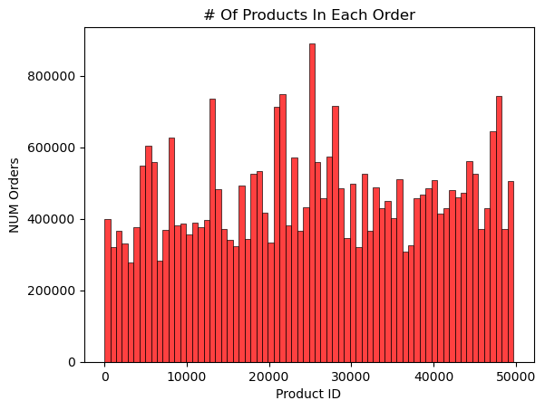

```python
# Recall the created data set that was prepared for later anaylsis.
dat = pd.merge(orders, orderproductsprior)  # Here we infact merging the data set.
prodcount = dat.groupby('order_id')['product_id'].count() # We see product count being through ID
recount = dat.groupby('product_id')['reordered'].sum() # We see product reorders being through ID

# The # of products within each order is show below illustrating the independecies.
sns.histplot(data=dat, x='product_id',  bins=70, color = "red")
plt.title("# Of Products In Each Order")
plt.xlabel("Product ID")
plt.ylabel("NUM Orders")
plt.show()
```

We can take a look at the days since previous reorders graphic to help us understand the relationships of variables within the data set. We create a histogram that illustrates the number of days that occur after each reorder. The histogram graphic is created below:

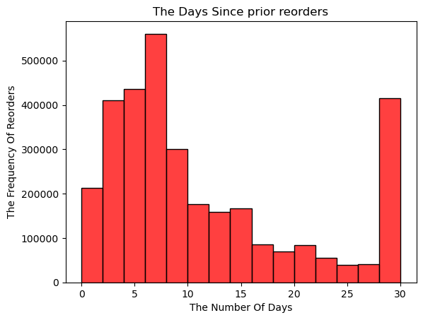

```python
sns.histplot(data=orders, x= 'days_since_prior_order',bins=15, color = "red")
plt.title("The Days Since prior reorders")
plt.xlabel("The Number Of Days")
plt.ylabel("The Frequency Of Reorders")
plt.show()
```

From this data set graphic, we can see that the data is right skewed with a particular outlier of 30 days since a particular frequency of reorders. It is very important to understand this because it helps us understand the data.

By modifying the data set using computational techniques, we were able to successfully solve this problem. In this step, the data set was modified, visualized, and understood using those particular techniques. By doing this, we were able to prepare the data set for analysis and use statistical and numerical techniques like regression and graphical displays without running into any issues in the previous problems. It is now possible to understand the relationship between the frequency of purchases, the quantity of products per order, and the number of reorders by changing the data.

## Problem II

II. The second problem is that we want to utilize linear equations and regression to later on predict the future reorder quantities for the commonly specified products.

Linear algebra is a branch of mathematics that is widely applied in a variety of fields. Linear algebra is essential to both machine learning and data science. A solid understanding of linear algebraic ideas will help you understand many data science and machine learning approaches. Before starting the regression and linear equation procedures we must follow up on modifying the data set by taking a look at particular metrics that will aid in regression and numerical interpretation.

- Throughout this numerical computational process we will utilize the 500 user data for the regression modeling and this can be found at [here](https://raw.githubusercontent.com/ykaih/AGEC317/master/Random_500users_train.csv).
- We must comprehend that this process will be very crucial throughout the statistical modeling and data analysis procedures.
- By addressing problem II we will be able to understand the results in python. But first we must continue altering the data.

We now need to read the data set. Following this procedure, we can display the regression results recurrently. This will make it easier to compose the linear model. This aids in our comprehension of the relationship and correlation between reorders, products, and the intervals between orders. This is important. We begin the computational procedure below.

```python
dataset = pd.read_csv('Downloads/Random_500users_train.csv')
results = sm.ols(formula="reorders ~ products + days_since_prior_order", data=dataset).fit()
print(results.params)

#Printing the results
```

```
Intercept                 0.347777
products                  0.679640
days_since_prior_order   -0.067168
dtype: float64
```

Due to the results obtained above, we can observe that there is a weak association between all three. Now we can examine the relationship between the items and reorders. In order to better comprehend the data, we can now perform exploratory data analysis on the goods and reorders. This leads to a definitive conclusion regarding the three connected variables, requiring us to search for fresh correlations over the entire set of data. This will be done by taking a look at the products and reorders.

Let us now conduct the regression results in python in order to tackle problem II. We will store the results in particular variables. This will make it easier for readability and for future reference across the projected data. We begin conducting the computational procedure to get the regression results below:

```python
Y = dataset['products'] # We identify the Y data set as products
X = dataset['reorders'] # We identify the x data set as reorders


# We add another columns for a regression constant. This is important in this process.
X = sma.add_constant(X)

#Here we are running our model and displaying the results.
model = sma.OLS(Y, X, missing='drop')
DAT = model.fit()
DAT.summary()
```

OLS Regression Results

| Dep. Variable: | products | R-squared: | 0.742 |
| --- | --- | --- | --- |
| Model: | OLS | Adj. R-squared: | 0.741 |
| Method: | Least Squares | F-statistic: | 1432. |
| Date: | Sun, 12 Mar 2023 | Prob (F-statistic): | 1.41e-148 |
| Time: | 13:47:58 | Log-Likelihood: | -1407.7 |
| No. Observations: | 500 | AIC: | 2819. |
| Df Residuals: | 498 | BIC: | 2828. |
| Df Model: | 1 |  |  |
| Covariance Type: | nonrobust |  |  |

|  | coef | std err | t | P>\|t\| | [0.025 | 0.975] |
| --- | --- | --- | --- | --- | --- | --- |
| const | 3.5890 | 0.257 | 13.944 | 0.000 | 3.083 | 4.095 |
| reorders | 1.0930 | 0.029 | 37.836 | 0.000 | 1.036 | 1.150 |

| Omnibus: | 77.911 | Durbin-Watson: | 2.114 |
| --- | --- | --- | --- |
| Prob(Omnibus): | 0.000 | Jarque-Bera (JB): | 111.421 |
| Skew: | 1.090 | Prob(JB): | 6.39e-25 |
| Kurtosis: | 3.771 | Cond. No. | 12.7 |

Notes:  
[1] Standard Errors assume that the covariance matrix of the errors is correctly specified.

The R squared score is 0.742, which indicates that there is a significant degree of connection between the variables. When determining how reorders connect to the product, this is essential information. The data regression's conclusion is important. 74% of the variance in the response variable can be explained by the explanatory variables. This is really important and crucial. To address problem II for the specific reorder amounts and product characteristics, we used linear regression functions in this process.

Now we will develop a regression line in order to udnerstand the correlation between both variables.

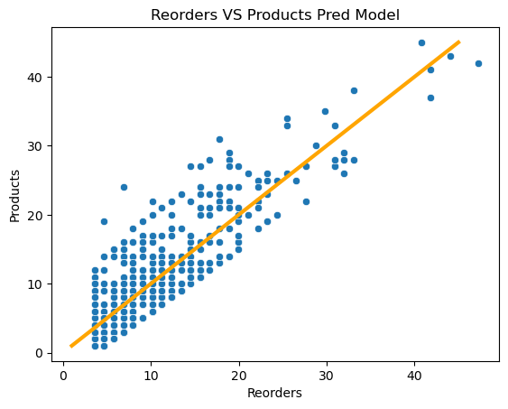

```python
Y = dataset['products'] # We identify the Y data set as products
X = dataset['reorders'] # We identify the x data set as reorders


# We add another columns for a regression constant. This is important in this process.
X = sma.add_constant(X)


# Here we apply the necessary computing in order to get the best regression results
Y_max = Y.max()
Y_min = Y.min()
fit = DAT.fittedvalues

#Labeling the results for readability
sns.scatterplot(x=fit, y=Y)
plt.title("Reorders VS Products Pred Model") #labels
plt.xlabel("Reorders") #labels
plt.ylabel("Products") #labels


plt.plot(np.linspace(Y_min, Y_max, 100),
         np.linspace(Y_min, Y_max, 100), color='orange', linewidth=3)
plt.show()
```

We will now identify the residual of the crated data set formed in problem I. We now must generate a qqplot below to understand the data given the regression results.

We form the qqplot below.

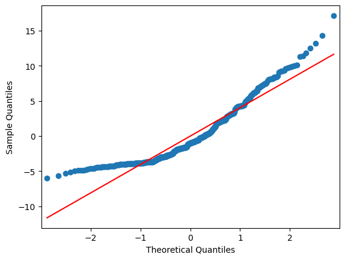

```python
residual = DAT.resid

sma.qqplot(residual, line='s');
```

The fact that this QQ plot depicts a curve indicates that the data is skewed. This is another evidence that the regression results and previous grpahics correctly depicts the data's skewed distribution. The points appear to fall roughly in a straight line at one position during the middle period of the data (0.5, 2), which may indicate that the distribution is normal at this location. Nonetheless, the data is appropriately biased because we look at the full image rather than just a particular area. The product and reorder data set is appropriately skewed. The graph above is another way to look at the data set and relationship between the observed variables. We were able to solve the second problem by utilizing linear equations and regression to predict the to later on predict the future reorder quantities for the commonly specified products.

## Problem III

III. The third problem is that we want to analyze the residuals and different graphic in order to better understand the distribution [1]. This will be done through different computational procedures that will underline the key variables present.

Now, we will manually conduct the regression process in order to better understand the relationship between the variable products and reorders. This help help us extracting the equation for us to predict the future sales (reorders). This is very important because it will help us understand the possible future revenue for Instacart as a company which will only benefit them in the future. We compute this process below:

```
The slope of this mathmatical model in b1 is 1.0930148326798628
The intercept of this mathmatical model in b0 is 3.589030079471109
```

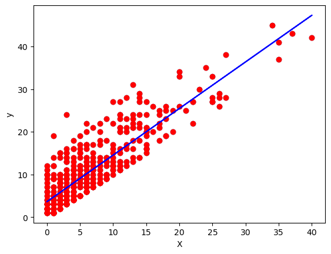

```python
#Here we form the statiscial vareiable labeling for the data sets.

y = dataset['products'] # We identify the Y data set as products
x = dataset['reorders'] # We identify the x data set as reorders
n = np.size(x) # n array

# Now we extract the means of particular variables
x_mean = np.mean(x)
y_mean = np.mean(y)
x_mean,y_mean

#Formulating the procedure of computational regression
A = np.sum(x*y)- n*x_mean*y_mean
B = np.sum(x*x)-n*x_mean*x_mean
b1 = A/B
b0 = y_mean-b1*x_mean

#Printing the particular evaluated quantities.
print('The slope of this mathmatical model in b1 is', b1)
print('The intercept of this mathmatical model in b0 is', b0)


#Plotting the data set with the title
plt.scatter(x,y)
plt.xlabel('The reorders')
plt.ylabel('The products')


#Formulating the prediction line of the set
y_pred = b1 * x + b0

#Finally graphing
plt.scatter(x, y, color = 'red')
plt.plot(x, y_pred, color = 'blue')
plt.xlabel('X')
plt.ylabel('y')
```

We are aware of the numerical advantage of including a constant. The difference may be seen in the addition of a "const" column of 1s to the original X matrix. Although linear regression really adds the properties of the best-fit line as well as uses the parameters to create forecasts, we may understand its purpose. A line's y-intercept as well as slope are its properties. Just a placeholder—a group of 1s to multiply the constant by—is provided in the "const" column. This demonstrates the value of including a constant. We compute this process below step by step:

```python
#Now we will add a constant.

X = sma.add_constant(X)
X.head()
```

|  | const | reorders |
| --- | --- | --- |
| 0 | 1.0 | 3 |
| 1 | 1.0 | 4 |
| 2 | 1.0 | 1 |
| 3 | 1.0 | 2 |
| 4 | 1.0 | 34 |

```python
#Recall the regression results

model = sma.OLS(Y, X, missing='drop')
model_result = model.fit()
model_result.summary()
```

OLS Regression Results

| Dep. Variable: | products | R-squared: | 0.742 |
| --- | --- | --- | --- |
| Model: | OLS | Adj. R-squared: | 0.741 |
| Method: | Least Squares | F-statistic: | 1432. |
| Date: | Sun, 12 Mar 2023 | Prob (F-statistic): | 1.41e-148 |
| Time: | 14:10:02 | Log-Likelihood: | -1407.7 |
| No. Observations: | 500 | AIC: | 2819. |
| Df Residuals: | 498 | BIC: | 2828. |
| Df Model: | 1 |  |  |
| Covariance Type: | nonrobust |  |  |

|  | coef | std err | t | P>\|t\| | [0.025 | 0.975] |
| --- | --- | --- | --- | --- | --- | --- |
| const | 3.5890 | 0.257 | 13.944 | 0.000 | 3.083 | 4.095 |
| reorders | 1.0930 | 0.029 | 37.836 | 0.000 | 1.036 | 1.150 |

| Omnibus: | 77.911 | Durbin-Watson: | 2.114 |
| --- | --- | --- | --- |
| Prob(Omnibus): | 0.000 | Jarque-Bera (JB): | 111.421 |
| Skew: | 1.090 | Prob(JB): | 6.39e-25 |
| Kurtosis: | 3.771 | Cond. No. | 12.7 |

Notes:  
[1] Standard Errors assume that the covariance matrix of the errors is correctly specified.

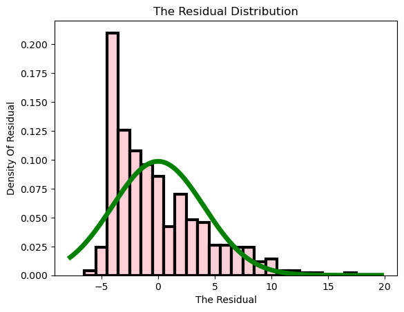

```python
# The mean & standard deviation for the best fit normal distribution.
#Addressing variables and adding details
residual = DAT.resid
fig, ax = plt.subplots();
mu, std = stats.norm.fit(residual);
sns.set_palette("deep")

# Forming the cumulative residual plot
sns.histplot(x=residual,
             ax=ax,
             stat="density",
             linewidth=3,
             fill= True,
             discrete= True,
             color = 'pink')

#Labeling the appropriate componenets of the graphic
plt.title("The Residual Distribution")
plt.xlabel("The Residual")
plt.ylabel("Density Of Residual")

# Now we plot the curve and add some details for graphical accuracy
xmin, xmax = plt.xlim()
x = np.linspace(xmin, xmax, 100000)
p = stats.norm.pdf(x, mu, std)
sns.lineplot(x=x,
             y=p,
             linewidth=5,
             color="green",
             ax=ax)
plt.show()
```

A fit plot contrasts actual values of Y with expected quantities of the response variable. All the measured values in a projected vs actual scatter graph will lie on the 45° diagonal if the linear regression model used is flawless, with the predicted values exactly matching the parameter estimates. In this case, it is clear that there is a significant and linearly positive relationship between the values. Let us observe a fit plot below.

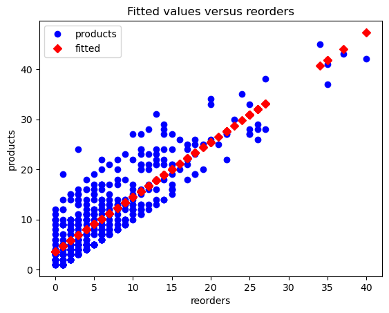

```python
sma.graphics.plot_fit(model_result,1, vlines=False);
```

The fit plot provides particular labeling and graphical representation. Once more it furthermore strengthens our analysis. We were able to solve the third problem by analyzing the residuals and different graphic which helped us understand the distribution [1]. This was be done through different computational procedures that underlined the key variables present.

## Problem IV

IV. The fourth problem is that we want to analyze the data using differentiation and optimization we want to assess the current existing models of the Instacart datasets and tackle the trouble that exists within them [6].

Without limits, it is impossible to do calculus or computational equations; limits are also necessary to compute continuity, derivatives, and integrals. A continuous function lacks abrupt changes in value, often known as discontinuities. How sensitive a function's value (or output value) is to changes in relation to other variables is measured by the derivative of a function of a real variable. Several independent variables are commonly needed for data science activities. Calculus uses the chain rule to express the derivative of an equation that comprises two or more variational functions in regards of the derivatives of the specific functions. The directional derivative of a multivariate differentiable (scalar) function over a given vector serves as an efficient way to gauge the rate of change of a function along a direction.

Regression analysis has been effectively used to identify the variables that influence the Instacart data set. The regression findings emphasized the interdependencies between products and reorders. This helped with the examination of the Instacart data set. We were able to determine with confidence which factors are most crucial, which ones may be ignored, and how the various components interact thanks to regression analysis [6]. Regression operations were carried out using linear equations in the examination of Instacart trends and forecasts. This procedure formed hypotheses, established rates, and carried out transformations [6]. It also explained the relationships between the variables in the data. We can understand several patterns and numerical values in the data by using differentiation computing to the Instacart regression technique. Providing the best model in light of a prioritized set of needs or constraints is the aim of optimization.

Now we recall the regression reuslts

```python
#Here we form the statistical variable labeling for the data sets.

y = dataset['products'] # We identify the Y data set as products
x = dataset['reorders'] # We identify the x data set as reorders
n = np.size(x)

# Now we extract the means
x_mean = np.mean(x)
y_mean = np.mean(y)
x_mean,y_mean

#Formulating the procedure
A = np.sum(x*y)- n*x_mean*y_mean
B = np.sum(x*x)-n*x_mean*x_mean

b1 = A/B
b0 = y_mean-b1*x_mean
print('The slope of this mathematical model in b1 is', b1)
print('The intercept of this mathematical model in b0 is', b0)


#Formulating the prediction line
y_pred = b1 * x + b0
```

```
The slope of this mathematical model in b1 is 1.0930148326798628
The intercept of this mathematical model in b0 is 3.589030079471109
```

Throughout the previous years researchers have managed to formulate particular mathematical models that address particular variables in the Instacart data set which focused on tackling the relationships between each variable. It is very important to understand how each Instacart data set variable interacts with one another because it can form particular conclusions about the true nature of the data set. The equation of the prediction line provided by the researchers concerning predicted product reorders is shown below [6].

```python
# Writing the equation provided by the researchers
AA = 1.437
BB = 4.489


#The equation is show below
y_research = (AA * X**2) + (BB*X)
```

Now we must compute the differentiation procedures with respect to the X variable given in the equation above. It is important to understand that this equation being derived will help us understand different components and interdependencies amongst the existing variables. It will help us draw conclusions and address current theories in this differentiation process. A function's rate of change or the slope of the tangent line at a certain point on a function are two ways to define a derivative. The rate of change with regard to a particular variable is revealed by a derivative. The rate of change with respect to the reorders will be revealed from the researchers developed equation and analysis.

Now we will conduct the differentiation process in order to address the rate of change of the intercept as well as slope throughout the Instacart regression equation.

```python
X = Symbol('X')
y_research = (AA * X**2) + (BB*X)
yprime = y_research.diff(X)

# computing numerically with the power rule method.

yprime
```

$\displaystyle 2.874 X + 4.489$

The following formula above is the result of differentiation the researchers equation of the rate of change with respect to the reorders.

Now let us plot the different regression graphics and research equations that were analyzed to compare the analyzed research results with the regression results that were created throughout this computation process. This will help us form particular conclusions and analysis that are very important concerning the Instacart data set.

```
   I. First we observe the original regression graphic that was created earlier.
```

```
The slope of this mathematical model in b1 is 1.0930148326798628
The intercept of this mathematical model in b0 is 3.589030079471109
```

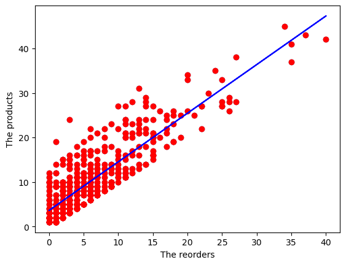

```python
#Here we form the statistical variable labeling for the data sets.

y = dataset['products'] # We identify the Y data set as products
x = dataset['reorders'] # We identify the x data set as reorders
n = np.size(x) # numpy array

# Now we extract the means and formulate the statistical procedure
x_mean = np.mean(x)
y_mean = np.mean(y)
x_mean,y_mean
A = np.sum(x*y)- n*x_mean*y_mean
B = np.sum(x*x)-n*x_mean*x_mean
b1 = A/B
b0 = y_mean-b1*x_mean


#Now we print the created results
print('The slope of this mathematical model in b1 is', b1)
print('The intercept of this mathematical model in b0 is', b0)


#Plotting the data set with the appropriate labels
plt.scatter(x,y)
plt.xlabel('The reorders')
plt.ylabel('The products')


#Formulating the prediction line
y_pred = b1 * x + b0

plt.scatter(x, y, color = 'red')
plt.plot(x, y_pred, color = 'blue')
plt.xlabel('The reorders')
plt.ylabel('The products')
```

```
   II.Secondly we observe the researched equation through a graphic that was created [6].
```

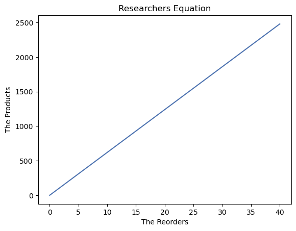

```python
#Addressing the existing variables throughout the equation for readability
AA = 1.437
BB = 4.489


#We create a function for refrence in order to deploy the equation graphic
def graph(formula, x_range):
    x = np.array(x_range)
    y = formula(x)
    plt.plot(x, y)
    plt.xlabel('The Reorders')
    plt.ylabel('The Products')
    plt.title("Researchers Equation")
    plt.show()

def my_formula(x):
    return (AA * x**2) + (BB*x)

#Calling the function and graphing with the appropriate reorder range interval
graph(my_formula, (0, 40))
```

```
   III. Thirdly we observe the researched equation that underwent differentation through a graphic that was created below [6].
```

```python
#Recall the differentiation

X = Symbol('X')
y_research = (AA * X**2) + (BB*X)
yprime = y_research.diff(X)
yprime

# computing numerically with the power rule method.
```

$\displaystyle 2.874 X + 4.489$

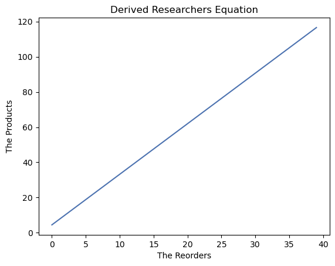

```python
#We create a function for refrence in order to deploy the equation graphic


def graph(formula, x_range):
    x = np.array(x_range)
    y = formula(x)
    plt.plot(x, y)
    plt.xlabel('The Reorders')
    plt.ylabel('The Products')
    plt.title("Derived Researchers Equation")
    plt.show()

def my_formula(x):
    return 2.874*x +4.489

#Calling the function and graphing with the appropriate reorder range interval
graph(my_formula, range(0, 40))
```

## Conclusion

The problems that were addressed throughout this paper are as follows:

[output not shown]

We utilized the following models and numerical methods:

```
I. Regression
        Finding the variables that have an effect on an interest issue was done with accuracy using regression analysis. The analysis of the Instacart data set was aided by this. Regression analysis enabled us to confidently assert which elements are most important, which factors can be disregarded, and how the various factors interacted [6].

II. Linear Equations
        The analysis of the Instacart patterns and predictions will heavily relied on linear equations. This method described the links between variables in the data, formed hypotheses, determined rates, and performed transformations [6].

III. Differentiation & Optimization
        We made sense of many patterns and numerical values in the data by differentiating them. The goal of optimization is to provide the optimal model in light of a list of prioritized requirements or restrictions. This will helped us with forecasting models [6].
```

Overall, we used the necessary frameworks and numerical techniques to handle all the issues raised throughout the study. In order to investigate the correlations between the important independent and dependent variables, we cleaned the lost data sets that were in various folders.

## Works Cited

- [1] “Instacart Market Basket Analysis | Kaggle,” Kaggle.com, 2023. [Online]. Available: https://www.kaggle.com/competitions/instacart-market-basket-analysis/data. [Accessed: Feb. 19, 2023]
- [2] “U.S. InstaCart grocery e-commerce sales 2019-2024 | Statista,” Statista, 2019. [Online]. Available: https://www.statista.com/statistics/1304265/instacart-grocery-sales-united-states/. [Accessed: Feb. 19, 2023]
- [3] “Instacart Revenue and Usage Statistics (2023),” Business of Apps, Sep. 29, 2020. [Online]. Available: https://www.businessofapps.com/data/instacart-statistics/. [Accessed: Feb. 19, 2023]
- [4] “Instacart,” Instacart, 2022. [Online]. Available: https://www.instacart.com/. [Accessed: Feb. 19, 2023]
- [5] J. Perri, “Instacart sales slow nationwide, but growth continues in some metros - Bloomberg Second Measure,” Bloomberg Second Measure, Apr. 28, 2022. [Online]. Available: https://secondmeasure.com/datapoints/instacart-sales-growth-nationwide-metro-areas/. [Accessed: Feb. 19, 2023]
- [6] “Python Programming And Numerical Methods: A Guide For Engineers And Scientists — Python Numerical Methods,” Berkeley.edu, 2020. [Online]. Available: https://pythonnumericalmethods.berkeley.edu/notebooks/Index.html. [Accessed: Feb. 19, 2023]